# Dynamic Harmonic Regression

Time Series

Dynamic Harmonic Regression for Time Series Data

Yeongeun Jeon , Jung In Seo  
06-12-2021

- Data 출처 : [Data Mining for Business Analytics](https://www.dataminingbook.com/book/r-edition)에서 사용한 미국 철도 회사 “Amtrak”에서 수집한 1991년 1월~2004년 3월까지 매달 환승 고객 수

# **Introduction**

- 기술이 점점 발달함에 따라 시계열 데이터들은 시간당, 분당, 초당으로 관측 가능해지며, 이렇게 관측된 시계열 데이터는 종종 긴 계절 주기를 가진다.
- `계절 주기가 길 때`, 계절성 ARIMA보다 선호되는 모델이 `Dynamic Harmonic Regression (DHR)`이다.
- 게다가, `다중 계절성`을 가진 시계열 데이터에도 DHR은 유용하다.
- DHR은 sine과 cosine 함수의 선형 조합으로써 `계절성을 설명하는 퓨리에 항(Fourier Terms)`을 가진 회귀 모형이다.
- 계절 주기가 $m$인 시계열 데이터 $Y_{t}$에 대한 DHR 모형식은 다음과 같다.

$$\begin{aligned}
Y_t = \beta_{0} + \sum^{K}_{i=1} \left[\alpha_{i,t} sin(2πit/m ) + \gamma_{i,t} cos(2πit/m ) \right] + \eta_t,
\end{aligned}$$

- $\alpha_{i,t}$ & $\gamma_{i,t}$ : 관측되지 않은 확률적 시간 변수 모수
- $K$ : sine과 cosine 쌍의 개수로써 $m/2$ 이하의 고정된 값
- $\eta_t$ : 오차로써 ARIMA 모형을 적합

# **Application**

- Ridership on Amtrak Trains(미국 철도 회사 “Amtrak”에서 수집한 1991년 1월~2004년 3월까지 매달 환승 고객 수) 예제를 이용하여 DHR이 실제 데이터에 어떻게 적용되는지 설명한다.

## **Data 불러오기**

```
pacman::p_load("forecast", "dplyr", "ggplot2", "xts")

# In Mac
# guess_encoding("Amtrak.csv")
# Amtrak.data <- read.csv("Amtrak.csv", fileEncoding="EUC-KR")

Amtrak.data <- data.table::fread(paste(getwd(),"Amtrak.csv", sep="/"))
ridership.ts <- ts(Amtrak.data$Ridership, start=c(1991,1), end=c(2004,3), freq=12)
```

## **Data 분할**

```
train.ts <- window(ridership.ts,start=c(1991,1), end=c(2001,3))
test.ts  <- window(ridership.ts,start=c(2001,4))
n.test   <- length(test.ts)
```

## **모형 적합**

- 퓨리에 항은 `forecast` package에 있는 `fourier` 함수를 이용한다.

[output not shown]

- x : 계절 주기를 가지는 시계열 데이터
- K : sine, cosine 쌍의 개수로써 시계열 데이터가 2개 이상의 계절 주기를 가질 때 계절 주기 개수만큼 필요
- h : 예측을 위한 주기 수

[output not shown]

```
Series: train.ts
Regression with ARIMA(5,1,2) errors

Coefficients:
          ar1      ar2      ar3      ar4     ar5     ma1     ma2
      -1.2069  -1.1238  -0.7371  -0.1625  0.3954  0.5535  0.3476
s.e.   0.1406   0.2021   0.2245   0.1960  0.1114  0.1599  0.0981
       drift     S1-12      C1-12     S2-12    C2-12
      0.4116  -52.3107  -107.3608  -35.2247  23.7494
s.e.  3.3551    8.9147     8.8901    5.8742   5.8703

sigma^2 estimated as 6143:  log likelihood=-701.65
AIC=1429.29   AICc=1432.66   BIC=1465.75
```

- 적합된 DHR 모형식은 다음과 같다.

$$\begin{aligned}
y_t &= 0.4116 -52.3107 sin(2\pi t/12 ) -107.3608 cos(2\pi t/12 ) -35.2247 sin(4\pi t/12) +23.7494 cos(4\pi t/12) + \eta_t, \\
\eta_t &= -1.2069\eta_{t-1} -1.1238\eta_{t-2}-0.7371\eta_{t-3}-0.1625\eta_{t-4} + 0.3954\eta_{t-5} + \epsilon_{t} +0.5535\epsilon_{t-1} + 0.3476\epsilon_{t-2},\\
\epsilon_{t} &\sim WN(0, 6143)
\end{aligned}$$

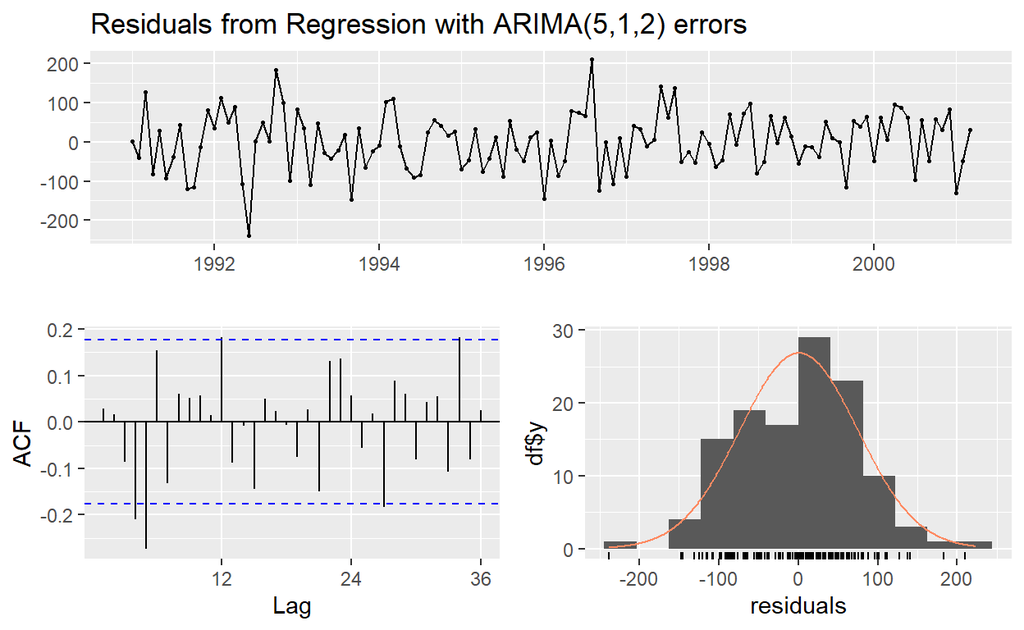

```
    Ljung-Box test

data:  Residuals from Regression with ARIMA(5,1,2) errors
Q* = 42.733, df = 12, p-value = 2.506e-05

Model df: 12.   Total lags used: 24
```

```
checkresiduals(DHR.fit)
```

## **예측**

```
DHR.forecast <- forecast(DHR.fit, xreg = fourier(train.ts, K=2, h=n.test) )
DHR.forecast$mean
```

```
          Jan      Feb      Mar      Apr      May      Jun      Jul
2001                            1990.590 2002.360 1939.015 2129.012
2002 1715.501 1701.942 1967.000 1997.213 2008.163 1980.212 2108.721
2003 1741.872 1731.747 1940.771 1999.742 2017.334 2010.164 2095.394
2004 1762.418 1754.637 1924.085
          Aug      Sep      Oct      Nov      Dec
2001 2098.128 1834.731 1910.820 1949.104 1955.958
2002 2073.729 1877.231 1916.445 1951.071 1930.820
2003 2057.557 1908.100 1924.888 1951.064 1914.886
2004
```

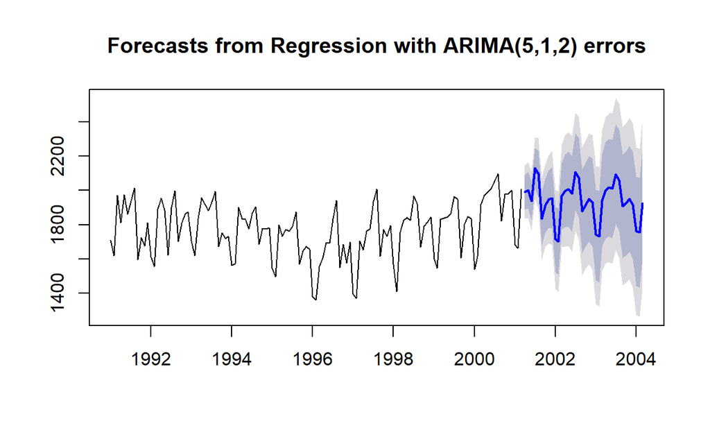

```
plot(DHR.forecast)
```

```
accuracy(test.ts, DHR.forecast$mean)
```

```
                ME     RMSE      MAE       MPE     MAPE      ACF1
Test set -55.08739 97.74112 79.85223 -2.835221 4.127865 0.3131728
         Theil's U
Test set 0.8378493
```

# **DHR With 예측 변수**

- Introduction에서 소개된 DHR 모형식은 $j$개의 예측 변수(Predictor Variable)들을 추가함으로써 다음과 같이 확장될 수 있다.

$$\begin{aligned}
Y_t = \beta_{0} + \sum_{i=1}^{j} \beta_{j}x_{i,t} + \sum^{K}_{i=1} \left[\alpha_{i,t} sin(2πit/m ) + \gamma_{i,t} cos(2πit/m ) \right] + \eta_t,
\end{aligned}$$

- $\alpha_{i,t}$ & $\gamma_{i,t}$ : 관측되지 않은 확률적 시간 변수 모수
- $\beta_{j}$ : 회귀계수
- $x_{i,t}$ : $i$번째 예측변수
- $K$ : sine과 cosine 쌍의 개수로써 $m/2$ 이하의 고정된 값
- $\eta_t$ : 오차로써 ARIMA 모형을 적합

> 위의 예제에 예측 변수가 있는 DHR을 적용해보았다.

## **예측 변수 생성**

```
## Month 변수 생성생성
xts(ridership.ts, order = as.Date(ridership.ts))
```

[output not shown]

[output cut: 105 more lines]

```
2003-01-01 1778.033
2003-02-01 1749.489
2003-03-01 2066.466
2003-04-01 2098.899
2003-05-01 2104.911
2003-06-01 2129.671
2003-07-01 2223.349
2003-08-01 2174.360
2003-09-01 1931.406
2003-10-01 2121.470
2003-11-01 2076.054
2003-12-01 2140.677
2004-01-01 1831.508
2004-02-01 1838.006
2004-03-01 2132.446
```

[output not shown]

## **모형 적합**

```
DHR.fit2 <- auto.arima(train.ts,
                       xreg = Train.Xreg,
                       seasonal = FALSE)
DHR.fit2
```

```
Series: train.ts
Regression with ARIMA(2,1,2) errors

Coefficients:
          ar1      ar2     ma1      ma2    Month     S1-12      C1-12
      -1.1998  -0.4967  0.2032  -0.4963  43.3345  109.4259  -150.3196
s.e.   0.1349   0.1294  0.1091   0.1353   9.2838   35.5583    12.9651
        S2-12     C2-12
      40.0290  -18.4092
s.e.  18.2969   12.3742

sigma^2 estimated as 9891:  log likelihood=-730.38
AIC=1480.76   AICc=1482.74   BIC=1508.8
```

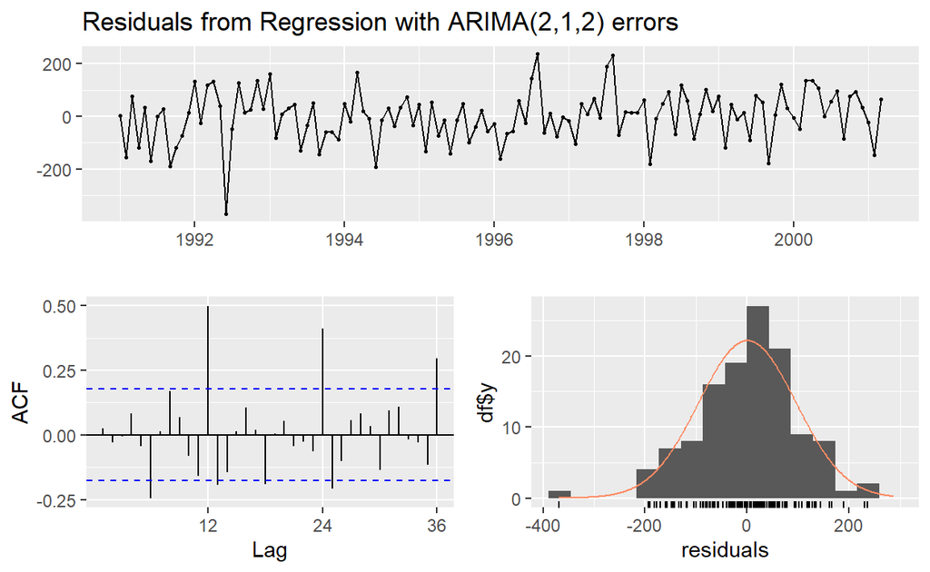

```
    Ljung-Box test

data:  Residuals from Regression with ARIMA(2,1,2) errors
Q* = 95.067, df = 15, p-value = 1.115e-13

Model df: 9.   Total lags used: 24
```

```
checkresiduals(DHR.fit2)
```

## **예측**

```
DHR.forecast2 <- forecast(DHR.fit2, xreg = Test.Xreg )
DHR.forecast2$mean
```

```
          Jan      Feb      Mar      Apr      May      Jun      Jul
2001                            1957.800 1980.577 2090.017 2020.626
2002 1651.827 1801.555 1912.521 1972.079 2010.833 2046.623 2057.661
2003 1647.319 1804.050 1911.767 1971.744 2011.609 2045.859 2058.193
2004 1647.258 1804.075 1911.768
          Aug      Sep      Oct      Nov      Dec
2001 2048.011 1943.821 1891.313 1907.054 1999.249
2002 2025.131 1952.878 1891.812 1901.957 2005.117
2003 2024.872 1952.924 1891.885 1901.846 2005.213
2004
```

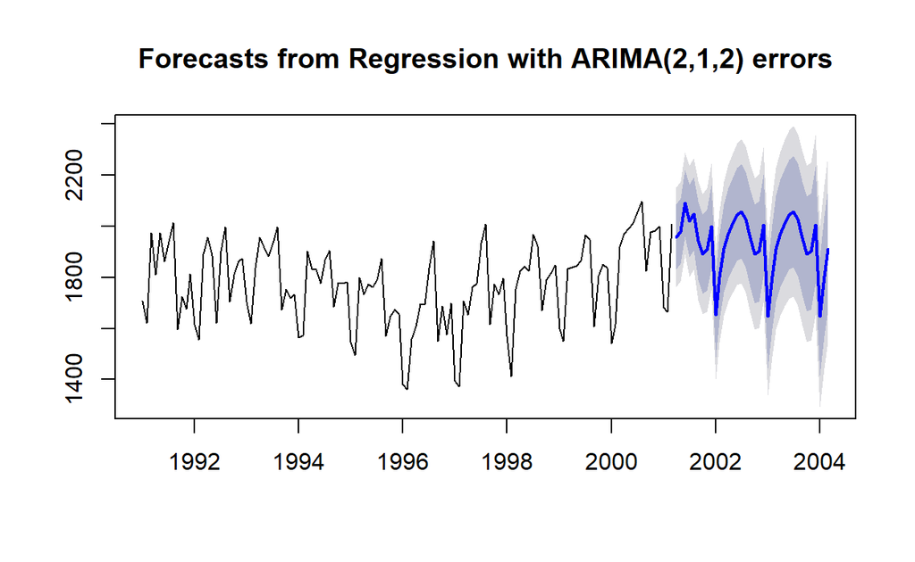

```
plot(DHR.forecast2)
```

```
accuracy(DHR.forecast2$mean, test.ts)
```

```
               ME     RMSE      MAE      MPE     MAPE       ACF1
Test set 58.24237 118.5707 97.03389 2.697112 4.885403 0.02801658
         Theil's U
Test set 0.6815818
```